# GRH Forecast Evaluation

Low-flow days only: days on which observed inflow stayed below 11,000 cfs at Wilder and Bellows Falls and below 14,000 cfs at Vernon

Report created: 2026-09-16 15:39:02.40891

## Metric Descriptions

- *NSE* - Nash-Sutcliffe Efficiency, a metric that measures performance relative to the mean of the data, values range from [-∞ , 1], with values greater than 0 indicating better performance than the mean, and a perfect forecast will have a value of 1.
- *KGE* - Kling-Gupta Efficiency, a metric that is often used similarly to NSE, but addresses several shortcomings by explicitly incorporating variability and correlation between simulations and observations. Values can range from [-∞ , 1] with negative values generally considered to indicate poor performance.
- *PBIAS* - Percent Bias, Bias of the simulation relative to the observations, represented as a percent. Negative values indicate a low bias and positive values indicate a high bias, values closer to 0 are preferable.
- *nRMSE* - Normalized root mean square error, expressed as a percent, lower values are better.
- *r* - Pearson’s correlation, a measure of how well the forecast and observations are correlated, values closer to 1 indicate better correlation.
- *rSD* - Ratio of standard deviations of forecast and observed. Values close to 1 are preferable as they indicate that the forecast has the same variability as the observations.

### Day Ahead Forecast Statistics

#### Overall

| source | location | NSE | KGE | PBIAS | nRMSE | r | rSD |
| --- | --- | --- | --- | --- | --- | --- | --- |
| A | wilder | 0.439 | 0.696 | -8.6 | 74.8 | 0.801 | 1.213 |
| B | wilder | 0.819 | 0.892 | -1.1 | 42.5 | 0.918 | 1.070 |
| GRH | wilder | 0.818 | 0.875 | -10.7 | 42.6 | 0.936 | 1.007 |
| perfect | wilder | 1.000 | 1.000 | 0.0 | 0.0 | 1.000 | 1.000 |
| persistence | wilder | -2.330 | -0.074 | -78.2 | 182.3 | 0.700 | 0.328 |
| A | bellows | -1.361 | -0.026 | 7.8 | 153.4 | 0.640 | 1.957 |
| B | bellows | 0.775 | 0.877 | 3.4 | 47.4 | 0.899 | 1.061 |
| GRH | bellows | 0.696 | 0.813 | -16.2 | 55.1 | 0.921 | 0.950 |
| perfect | bellows | 1.000 | 1.000 | 0.0 | 0.0 | 1.000 | 1.000 |
| persistence | bellows | 0.123 | 0.537 | -30.9 | 93.5 | 0.851 | 0.690 |
| A | vernon | 0.534 | 0.696 | -11.9 | 68.2 | 0.868 | 1.247 |
| B | vernon | 0.709 | 0.771 | 7.6 | 53.9 | 0.907 | 1.195 |
| GRH | vernon | 0.705 | 0.815 | -16.9 | 54.3 | 0.927 | 0.982 |
| perfect | vernon | 1.000 | 1.000 | 0.0 | 0.0 | 1.000 | 1.000 |
| persistence | vernon | 0.792 | 0.827 | -10.8 | 45.5 | 0.926 | 0.888 |

#### Winter

| source | location | season | NSE | KGE | PBIAS | nRMSE | r | rSD |
| --- | --- | --- | --- | --- | --- | --- | --- | --- |
| A | wilder | winter | -1.010 | 0.035 | 3.1 | 140.9 | 0.698 | 1.916 |
| B | wilder | winter | 0.653 | 0.697 | -3.6 | 58.8 | 0.899 | 1.283 |
| GRH | wilder | winter | 0.595 | 0.796 | -10.5 | 63.2 | 0.896 | 1.142 |
| perfect | wilder | winter | 1.000 | 1.000 | 0.0 | 0.0 | 1.000 | 1.000 |
| persistence | wilder | winter | -2.993 | -0.035 | -75.3 | 199.2 | 0.804 | 0.319 |
| A | bellows | winter | -55.565 | -3.320 | 68.3 | 743.7 | 0.075 | 5.164 |
| B | bellows | winter | 0.814 | 0.890 | -4.9 | 43.0 | 0.913 | 0.952 |
| GRH | bellows | winter | -1.036 | 0.576 | -13.3 | 141.1 | 0.677 | 1.241 |
| perfect | bellows | winter | 1.000 | 1.000 | 0.0 | 0.0 | 1.000 | 1.000 |
| persistence | bellows | winter | -0.277 | 0.447 | -34.4 | 112.5 | 0.853 | 0.593 |
| A | vernon | winter | -2.574 | -0.088 | 16.2 | 187.0 | 0.627 | 2.009 |
| B | vernon | winter | 0.824 | 0.818 | -1.4 | 41.8 | 0.938 | 1.171 |
| GRH | vernon | winter | -0.459 | 0.673 | -14.1 | 119.5 | 0.725 | 1.107 |
| perfect | vernon | winter | 1.000 | 1.000 | 0.0 | 0.0 | 1.000 | 1.000 |
| persistence | vernon | winter | 0.830 | 0.826 | -9.6 | 41.0 | 0.948 | 0.865 |

#### Spring

| source | location | season | NSE | KGE | PBIAS | nRMSE | r | rSD |
| --- | --- | --- | --- | --- | --- | --- | --- | --- |
| A | wilder | spring | 0.631 | 0.656 | -3.4 | 60.1 | 0.908 | 1.330 |
| B | wilder | spring | 0.749 | 0.852 | 0.0 | 49.8 | 0.890 | 1.100 |
| GRH | wilder | spring | 0.794 | 0.891 | -6.5 | 45.0 | 0.928 | 1.049 |
| perfect | wilder | spring | 1.000 | 1.000 | 0.0 | 0.0 | 1.000 | 1.000 |
| persistence | wilder | spring | -6.526 | -0.114 | -78.4 | 272.3 | 0.599 | 0.318 |
| A | bellows | spring | 0.696 | 0.854 | -2.6 | 53.7 | 0.857 | 1.014 |
| B | bellows | spring | 0.669 | 0.680 | 4.0 | 56.5 | 0.919 | 1.308 |
| GRH | bellows | spring | 0.078 | 0.697 | -13.2 | 93.6 | 0.727 | 0.985 |
| perfect | bellows | spring | 1.000 | 1.000 | 0.0 | 0.0 | 1.000 | 1.000 |
| persistence | bellows | spring | -0.911 | 0.598 | -31.6 | 135.6 | 0.848 | 0.803 |
| A | vernon | spring | 0.351 | 0.708 | -9.3 | 78.8 | 0.820 | 1.211 |
| B | vernon | spring | 0.495 | 0.577 | 8.6 | 69.9 | 0.916 | 1.406 |
| GRH | vernon | spring | 0.198 | 0.735 | -13.1 | 87.6 | 0.815 | 1.136 |
| perfect | vernon | spring | 1.000 | 1.000 | 0.0 | 0.0 | 1.000 | 1.000 |
| persistence | vernon | spring | 0.585 | 0.825 | -13.4 | 63.3 | 0.917 | 0.922 |

#### Summer

| source | location | season | NSE | KGE | PBIAS | nRMSE | r | rSD |
| --- | --- | --- | --- | --- | --- | --- | --- | --- |
| A | wilder | summer | -0.003 | 0.560 | -12.7 | 99.8 | 0.668 | 1.259 |
| B | wilder | summer | 0.730 | 0.848 | -0.7 | 51.8 | 0.859 | 0.943 |
| GRH | wilder | summer | 0.686 | 0.828 | -12.5 | 55.9 | 0.898 | 1.062 |
| perfect | wilder | summer | 1.000 | 1.000 | 0.0 | 0.0 | 1.000 | 1.000 |
| persistence | wilder | summer | -3.664 | -0.083 | -78.9 | 215.2 | 0.525 | 0.430 |
| A | bellows | summer | -2.192 | -0.180 | 1.7 | 177.8 | 0.507 | 2.072 |
| B | bellows | summer | 0.569 | 0.763 | 5.1 | 65.3 | 0.835 | 1.162 |
| GRH | bellows | summer | 0.555 | 0.796 | -18.4 | 66.4 | 0.913 | 1.022 |
| perfect | bellows | summer | 1.000 | 1.000 | 0.0 | 0.0 | 1.000 | 1.000 |
| persistence | bellows | summer | 0.116 | 0.650 | -25.2 | 93.6 | 0.802 | 0.859 |
| A | vernon | summer | 0.260 | 0.658 | -16.2 | 85.6 | 0.807 | 1.231 |
| B | vernon | summer | 0.453 | 0.676 | 8.6 | 73.6 | 0.836 | 1.265 |
| GRH | vernon | summer | 0.532 | 0.784 | -18.2 | 68.1 | 0.905 | 1.067 |
| perfect | vernon | summer | 1.000 | 1.000 | 0.0 | 0.0 | 1.000 | 1.000 |
| persistence | vernon | summer | 0.665 | 0.832 | -10.1 | 57.6 | 0.871 | 0.964 |

#### Fall

| source | location | season | NSE | KGE | PBIAS | nRMSE | r | rSD |
| --- | --- | --- | --- | --- | --- | --- | --- | --- |
| A | wilder | fall | 0.633 | 0.682 | -15.2 | 60.4 | 0.873 | 0.751 |
| B | wilder | fall | 0.891 | 0.920 | 0.8 | 33.0 | 0.950 | 1.062 |
| GRH | wilder | fall | 0.789 | 0.854 | -11.1 | 45.8 | 0.923 | 0.945 |
| perfect | wilder | fall | 1.000 | 1.000 | 0.0 | 0.0 | 1.000 | 1.000 |
| persistence | wilder | fall | -3.011 | -0.115 | -81.0 | 199.7 | 0.705 | 0.293 |
| A | bellows | fall | 0.589 | 0.712 | -14.5 | 63.9 | 0.827 | 0.821 |
| B | bellows | fall | 0.798 | 0.843 | 9.6 | 44.8 | 0.933 | 1.105 |
| GRH | bellows | fall | 0.705 | 0.792 | -16.6 | 54.2 | 0.910 | 0.913 |
| perfect | bellows | fall | 1.000 | 1.000 | 0.0 | 0.0 | 1.000 | 1.000 |
| persistence | bellows | fall | 0.219 | 0.469 | -32.0 | 88.1 | 0.886 | 0.593 |
| A | vernon | fall | 0.656 | 0.757 | -22.5 | 58.5 | 0.923 | 0.950 |
| B | vernon | fall | 0.703 | 0.732 | 14.5 | 54.3 | 0.931 | 1.215 |
| GRH | vernon | fall | 0.742 | 0.801 | -18.0 | 50.7 | 0.930 | 0.953 |
| perfect | vernon | fall | 1.000 | 1.000 | 0.0 | 0.0 | 1.000 | 1.000 |
| persistence | vernon | fall | 0.796 | 0.797 | -11.8 | 45.1 | 0.926 | 0.852 |

### Error Distributions (Forecast - Observed)

#### Overall

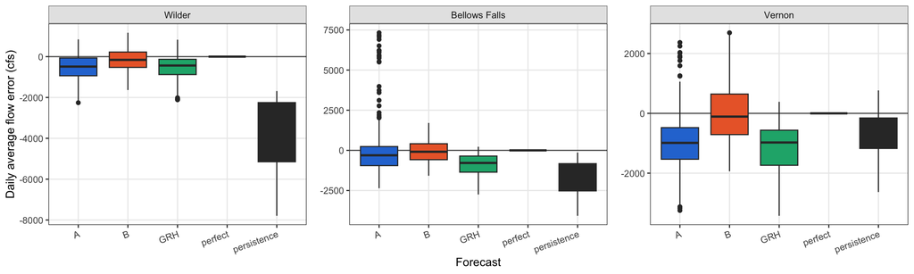

#### Winter

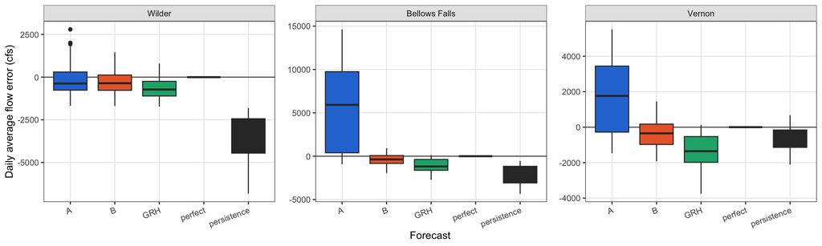

#### Spring

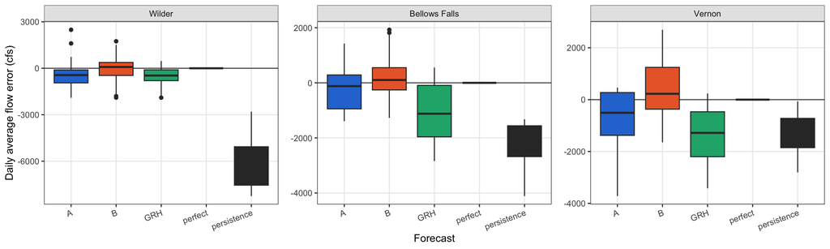

#### Summer

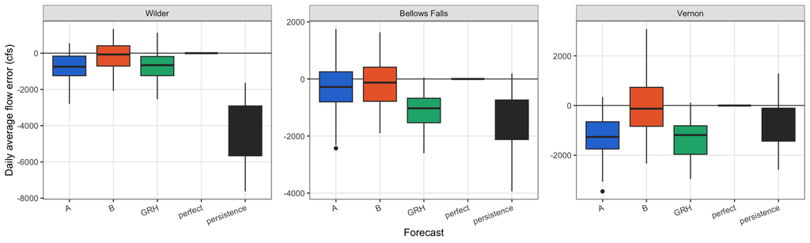

#### Fall

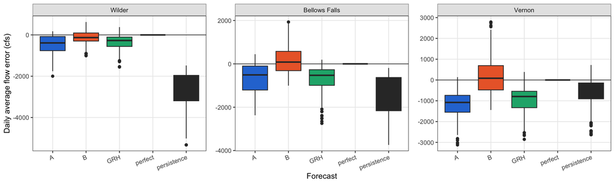

### Day Ahead Observed vs. Forecast Scatterplot

#### Overall

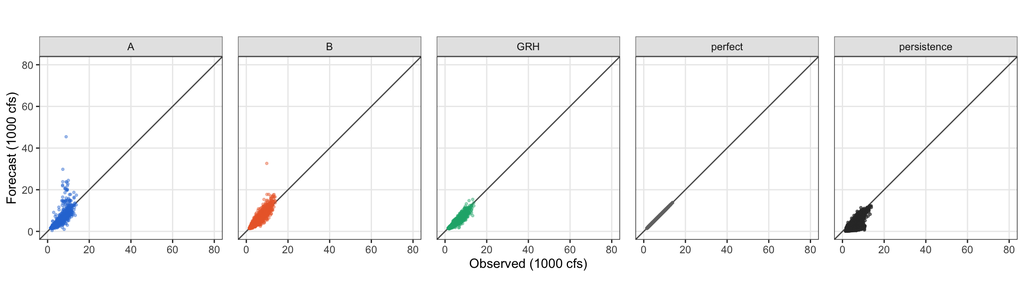

#### Winter

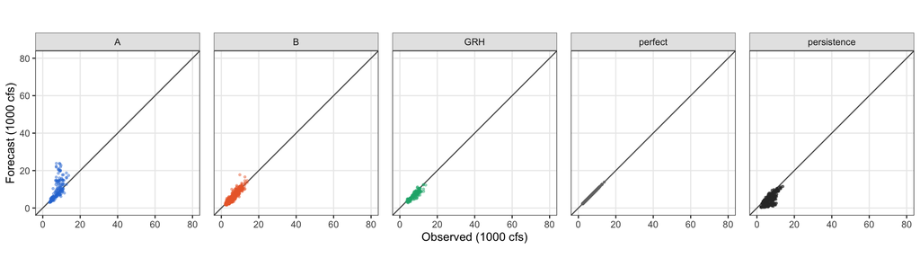

#### Spring

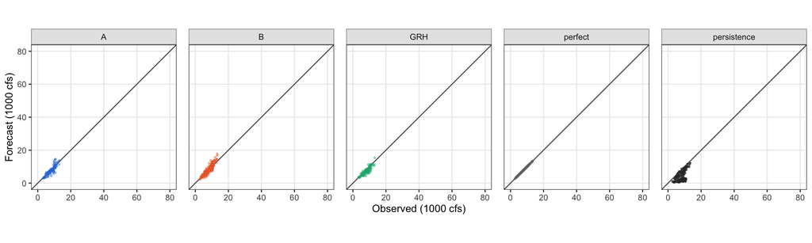

#### Summer

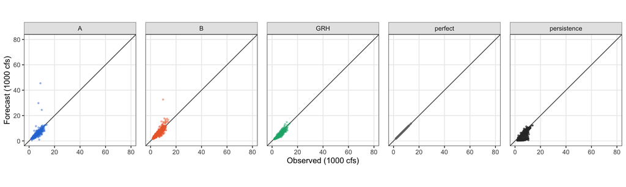

#### Fall

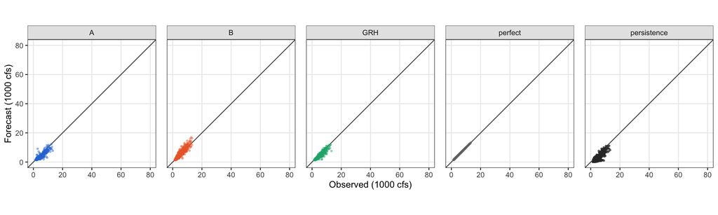

### Day Ahead Performance by Month

Paper Figure 4 is this plot for the four metrics below.

#### Kling-Gupta Efficiency (KGE)

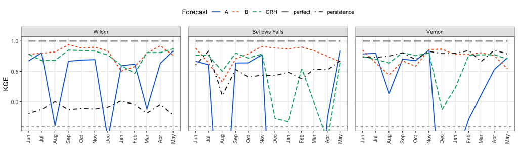

#### Nash-Suttecliffe Efficiency (NSE)

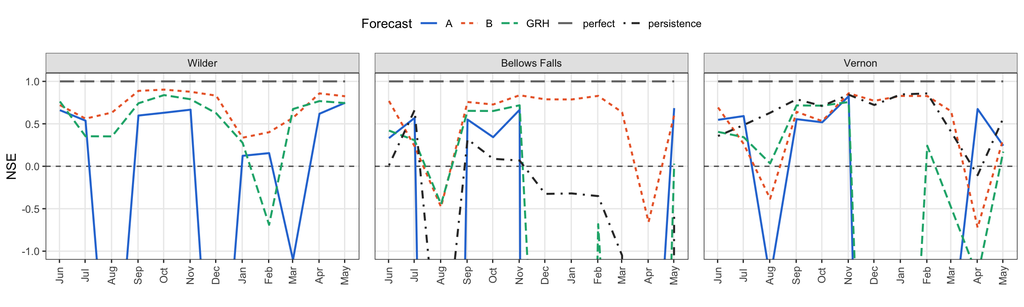

#### Pearson’s Correlation (r)

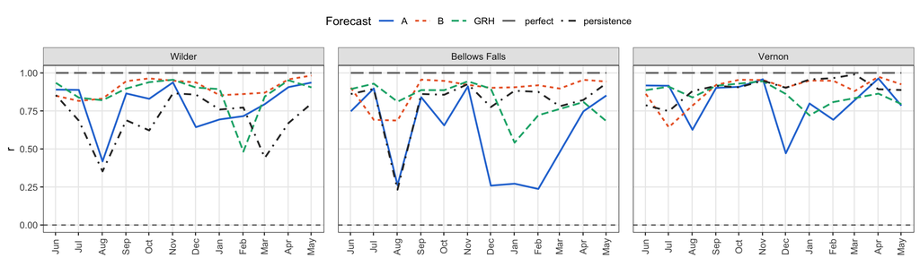

#### Percent Bias

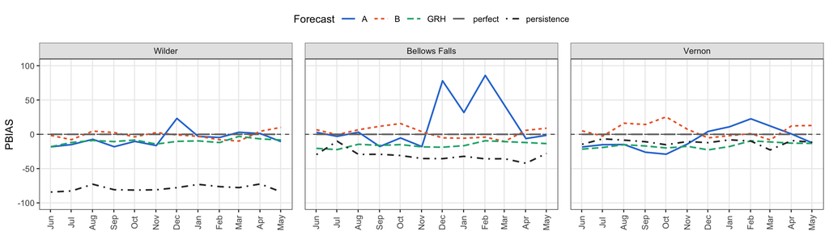

## Daily forecast performance vs lead time

Paper Figure 3 is the “Overall” tab of each metric below.

### Kling-Gupta Efficiency (KGE)

#### Overall

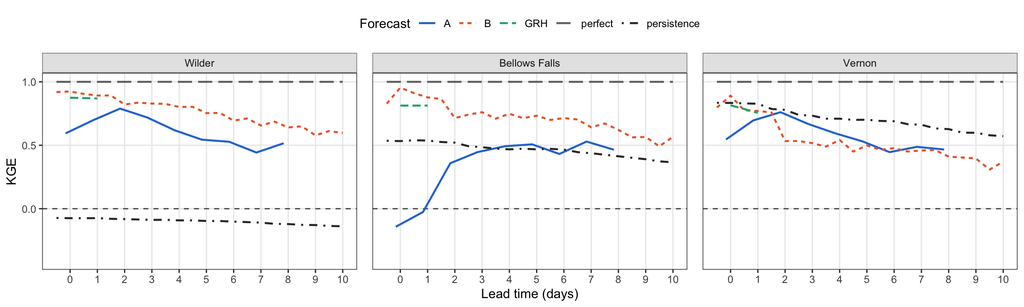

#### Winter

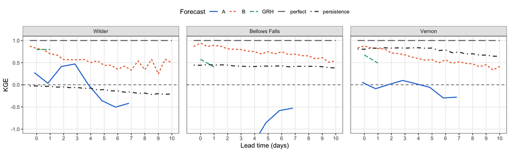

#### Spring

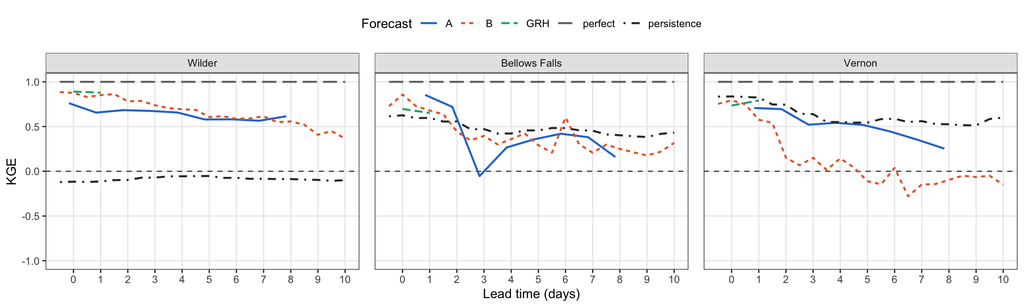

#### Summer

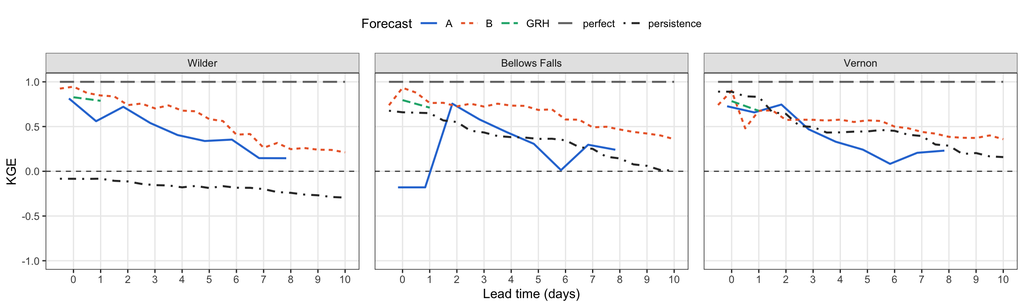

#### Fall

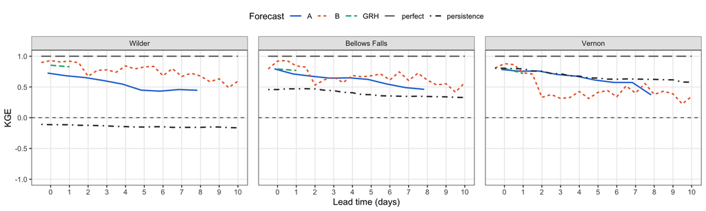

### Nash-Suttecliffe Efficiency (NSE)

#### Overall

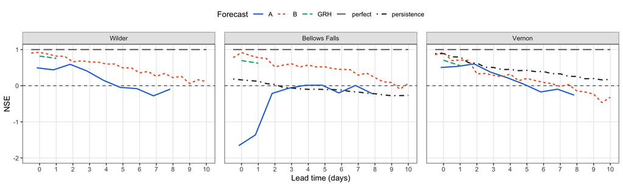

#### Winter

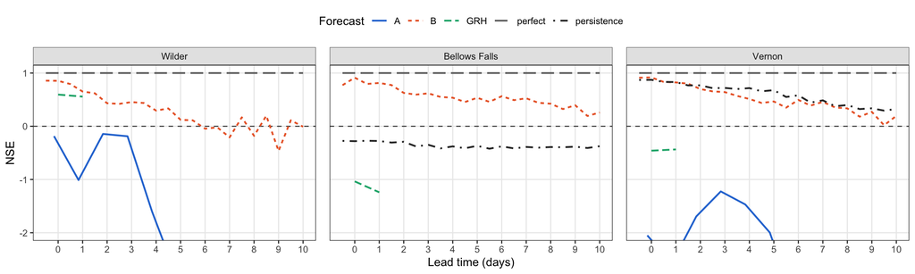

#### Spring

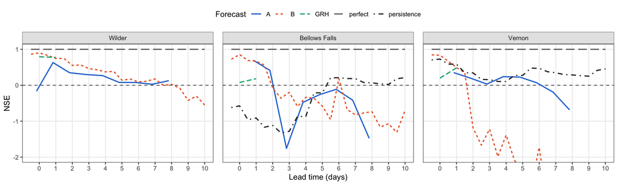

#### Summer

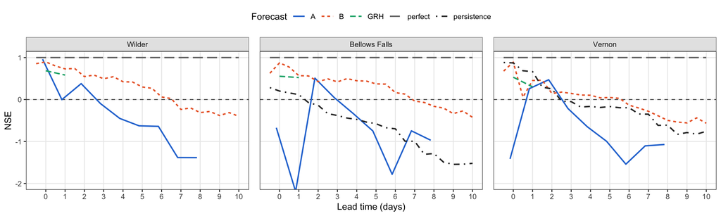

#### Fall

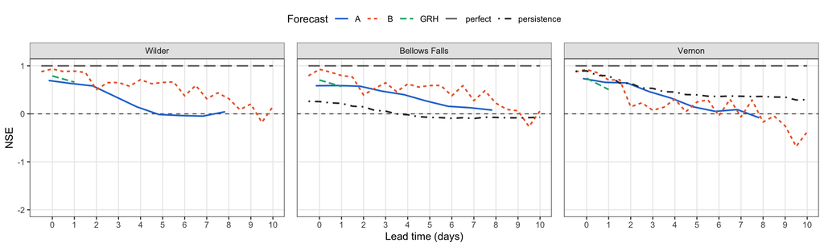

### Pearson’s Correlation (r)

#### Overall

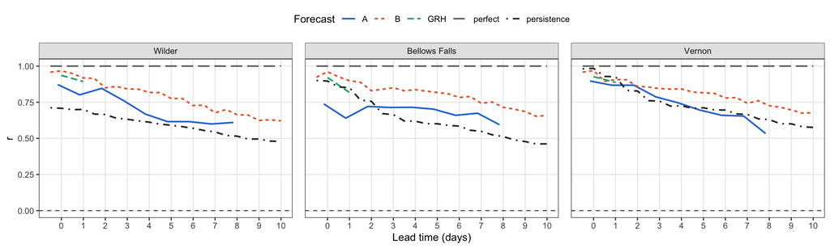

#### Winter

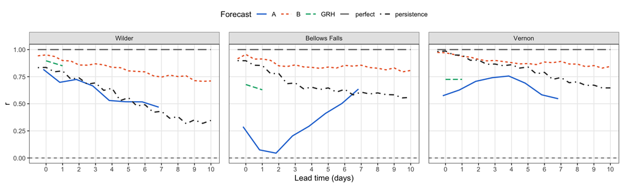

#### Spring

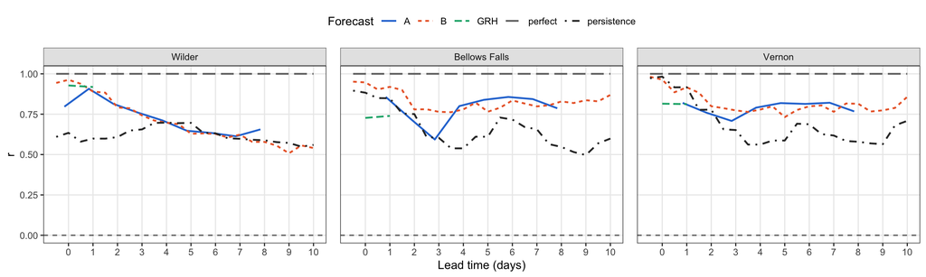

#### Summer

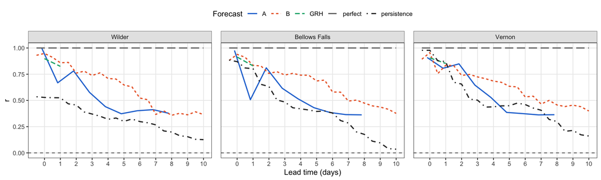

#### Fall

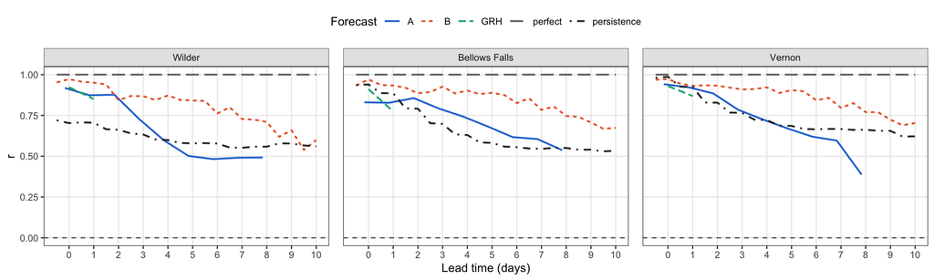